# Tennis, what’s up with second serves?

Jeremy Klein

May 18, 2018

## 1 - The Question

My family has always been interested in tennis. My brother, mother and father all play, and even though I don’t play, I still enjoy spectating it. After watching countless hours on television, I started to wonder about the effectiveness of the second serve. Whenever they displayed match data the first serve always had a huge win rate, leading me to theorize that serving your first serve for your second serve would yield a higher win rate.

For those with little tennis background if you miss your first serve you are allowed to take a second serve. However if the first serve was returned by your opponent you do not get a second serve. This means players are allowed to be a little riskier with their first serve.

Naturally just about everyone attempts their second serve with caution. It is usually much slower and easy to return than first serves. Since they are easier to return, your second serve will not win as much as your first one. The question is; does a conservative second serve give you better odds at winning over a second first serve?

I will analyse whether serving a weak second serve actually helps or if you should just slam that second serve.

## 2 - The Method

To determine if you are hurting your overall win rate with your second serve, I will be analysing data to find out basic win rate in comparison to first serve and second serve.

## 3 - The Data

I will be using data from the 2011 Australian Open provided by Jeff Sackmann. He has a lot of tennis data on his github, including the data I am using, found [here](https://github.com/JeffSackmann/tennis_slam_pointbypoint/). Sadly we have to use an older dataset because he does not have first and second serve data for the later years.

## 4 - Our workstation

We will be using tidyverse, an extremely useful R package which has many contains many libraries with tools for data manipulation. You can download R [here](https://www.r-project.org/) and learn about tidyverse [here](https://www.tidyverse.org/).

```r
library(tidyverse)
db <- read_csv("C:/Users/Jeremy/Desktop/CMSC320/Final Project/2011-ausopen-points.csv")
```

## 5.1 - Data Manipulation

To start our journey we will have to manipulate the data to contain our desired statistics. Usually the first step is collecting the data, but thanks to Jeff, we can dive right in!

The first thing I will do is create a new dataframe to contain only our first serve and second serve win rate. To do this we have to trim out the unnecessary data and derive a new statistic that shows first and second serve win rates.

We want to count a missed first serve as a loss. If we don’t, then we wouldn’t be able to compare first and second serve win rates since first serve wins would include all second serve wins. We also want to make our model based off of serves in general. This means I will change the entities (table entries) to describe players serves instead of player 1 vs player 2.

Some attributes that I think would be interesting to preserve and maybe analyse are ace, breakpoint and speed in MPH.

```r
db <- db %>%
  mutate("ServerWon" = if_else(PointWinner == PointServer, 1, 0)) %>%
  mutate("BreakPoint" = if_else(P1BreakPoint == 1 | P2BreakPoint == 1, 1, 0)) %>%
  mutate("Ace" = if_else(P1Ace == 1 | P2Ace == 1, 1, 0)) %>%
  mutate("DoubleFault" = if_else(P1DoubleFault == 1 | P2DoubleFault == 1, 1, 0)) %>%
  mutate("FirstServeIn" = if_else(P1FirstSrvIn == 1 | P2FirstSrvIn == 1, 1,0)) %>%
  mutate("FirstServeWon" = if_else(P1FirstSrvWon == 1 | P2FirstSrvWon == 1, 1, 0)) %>%
  mutate("SecondServeIn" = if_else(P1SecondSrvIn == 1 | P2SecondSrvIn == 1, 1, 0)) %>%
  mutate("SecondServeWon" = if_else(P1SecondSrvWon == 1 | P2SecondSrvWon == 1, 1, 0)) %>%
  select(ServerWon, BreakPoint, Ace, DoubleFault, Speed_MPH, FirstServeIn, FirstServeWon, SecondServeIn, SecondServeWon)

sample(db)
```

```
## # A tibble: 31,523 x 9
##    BreakPoint DoubleFault SecondServeIn FirstServeWon SecondServeWon
##         <dbl>       <dbl>         <dbl>         <dbl>          <dbl>
##  1          0           0             0             0              0
##  2          0           0             0             0              0
##  3          0           0             1             0              0
##  4          0           0             1             0              0
##  5          1           0             1             0              0
##  6          0           0             1             0              1
##  7          0           0             0             1              0
##  8          0           1             0             0              0
##  9          0           0             0             1              0
## 10          0           0             0             0              0
## # ... with 31,513 more rows, and 4 more variables: ServerWon <dbl>,
## #   FirstServeIn <dbl>, Speed_MPH <int>, Ace <dbl>
```

## 5.2 - Data Manipulation

To the untrained eye, this data looks great, but realistically this data is not helpful! The data we have comes from a point-by-point dataset so this trimmed data still models point-by-point. We want serve data instead of point-by-point data. Since a single point can describe two serves, this dataset is not tidy and we need to clean it up!

To clean it up we are going to have to transform it again to describe each serve rather than each point. We will need to make a few new variables. We also have to make sure we are careful about serve speed since it is only relevant to the last serve that was served in.

#### Data Science Terminology

The reason why we have do this second mutation is because our current data is not a tidy model of what we want.

Tidy data follows a few basic rules,

1. Each variable should be in one column.
2. Each observation of a variable should be in a different row.

Our previous model actually followed the first rule just fine. It didn’t follow the second rule very well. Our observations are over serves since we want to do our analytics over serves. Since a single point can have up to two serves our dataset is far from tidy!

Also, since we are definitely going to show off our interesting data, we should learn the fancy terms to talk about these variables!

Here’s quick overview on variable types:

- Categorical - A variable that defines membership of a class
  - A good example is our new serve variable.
- Discrete Numeric - A numeric variable that takes a specific value
  - We actually don’t have anything that falls into this category.
- Continuous Numeric - A numeric variable that takes a value in a range
  - MPH is our only continuous variable in our new model.

Now the question is how do we describe Won, Ace and BreakPoint? Right now they take the value of either 0 or 1 and describes categories. Since it is numeric it should fall under the Discrete Numeric category, but it also is describing a class so it should fall under the Categorical category.

The way to determine if they are Discrete Numeric or Categorical is by what they describe. If there is a magnitude to the variables (ex. the value it takes shows how much weight it should hold) then it should be Discrete Numeric. However Won, Ace and BreakPoint really only show binary classes we will consider them to be categorical and change their values to True/False to represent them better.

#### First let’s tidy our dataset

```r
db <- db %>%
  mutate("Serve" = if_else(FirstServeIn == 1, "First", "Second")) %>%
  mutate("Won" = ServerWon) %>%
  select(Serve, Won, BreakPoint, Ace, DoubleFault, Speed = Speed_MPH)
```

#### Remove any observations without serve data

```r
db <- db[complete.cases(db["Serve"]),]
```

#### Now we have to include a copy of all second serves as first serve losses

```r
db <- db %>%
  rbind(db %>%
          filter(Serve == "Second") %>%
          mutate(Serve = "First") %>%
          mutate(Won = 0) %>%
          mutate(DoubleFault = 0) %>%
          mutate(Ace = 0) %>%
          mutate(Speed = 0))

sample(db)
```

```
## # A tibble: 43,582 x 6
##    Serve  Speed DoubleFault BreakPoint   Won   Ace
##    <chr>  <dbl>       <dbl>      <dbl> <dbl> <dbl>
##  1 Second     0           0          0     1     0
##  2 First    103           0          0     0     0
##  3 Second    82           0          0     0     0
##  4 Second    89           0          0     0     0
##  5 Second    85           0          1     0     0
##  6 Second    92           0          0     1     0
##  7 First    124           0          0     1     0
##  8 Second     0           1          0     0     0
##  9 First    106           0          0     1     1
## 10 First    124           0          0     0     0
## # ... with 43,572 more rows
```

#### Lets change our DoubleFault, BreakPoint, Ace and Won variables to True and False representations now

```r
db$DoubleFault <- db$DoubleFault == 1
db$BreakPoint <- db$BreakPoint == 1
db$Ace <- db$Ace == 1
db$Won <- db$Won == 1

sample(db)
```

```
## # A tibble: 43,582 x 6
##    Ace   Won   DoubleFault Speed Serve  BreakPoint
##    <lgl> <lgl> <lgl>       <dbl> <chr>  <lgl>
##  1 FALSE TRUE  FALSE           0 Second FALSE
##  2 FALSE FALSE FALSE         103 First  FALSE
##  3 FALSE FALSE FALSE          82 Second FALSE
##  4 FALSE FALSE FALSE          89 Second FALSE
##  5 FALSE FALSE FALSE          85 Second TRUE
##  6 FALSE TRUE  FALSE          92 Second FALSE
##  7 FALSE TRUE  FALSE         124 First  FALSE
##  8 FALSE FALSE TRUE            0 Second FALSE
##  9 TRUE  TRUE  FALSE         106 First  FALSE
## 10 FALSE FALSE FALSE         124 First  FALSE
## # ... with 43,572 more rows
```

#### Finally lets make all observations with a seve speed of 0 to N/A

```r
db$Speed[db$Speed == 0] <- NA

sample(db)
```

```
## # A tibble: 43,582 x 6
##    Won   Serve  Speed Ace   DoubleFault BreakPoint
##    <lgl> <chr>  <dbl> <lgl> <lgl>       <lgl>
##  1 TRUE  Second    NA FALSE FALSE       FALSE
##  2 FALSE First    103 FALSE FALSE       FALSE
##  3 FALSE Second    82 FALSE FALSE       FALSE
##  4 FALSE Second    89 FALSE FALSE       FALSE
##  5 FALSE Second    85 FALSE FALSE       TRUE
##  6 TRUE  Second    92 FALSE FALSE       FALSE
##  7 TRUE  First    124 FALSE FALSE       FALSE
##  8 FALSE Second    NA FALSE TRUE        FALSE
##  9 TRUE  First    106 TRUE  FALSE       FALSE
## 10 FALSE First    124 FALSE FALSE       FALSE
## # ... with 43,572 more rows
```

## 6 - Visualizing our Data

Now that we have a nice and tidy dataset that represents all the data we are trying to encapsulate, lets make some graphs over them.

Lets first make a basic graph of first serve win rate and second serve win rate.

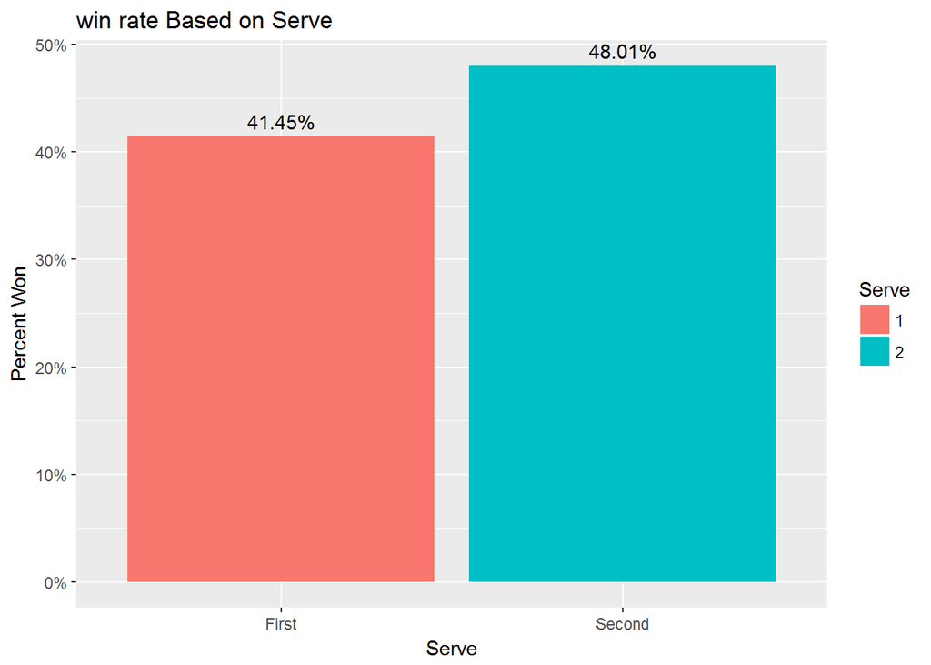

```r
db %>%
  group_by(Serve) %>%
  count(Won) %>%
  mutate("perc" = n/sum(n)) %>%
  filter(Won == TRUE) %>%
  ggplot(aes(x = Serve, y = perc)) +
    geom_col(aes(fill = factor(..x..))) +
    scale_y_continuous(labels=scales::percent) +
    ggtitle("win rate Based on Serve") +
    geom_text(aes(label = scales::percent(perc), vjust = -.5)) +
    labs(y = "Percent Won", fill = "Serve")
```

We got our basic graph down, let’s see what we learn from it. So it shouldn’t be too surprising that second serves do have a higher win rate than first serves. If they didn’t then there wouldn’t be any reason to slow down your second serve!

I’m definitely a little disappointed since I enjoy watching super spicy first serves, served up with extra heat.

Overall our first serves have a lower success but I believe this is different than the television statistic because we considered missed first serves as losses. Lets see what happens if we graph our first serve win rate to account only for serves that were in.

Since we know all second serves start with a first serve that is out, we can remove the total number of second serves from our first serve losses to determine all first serves that are in

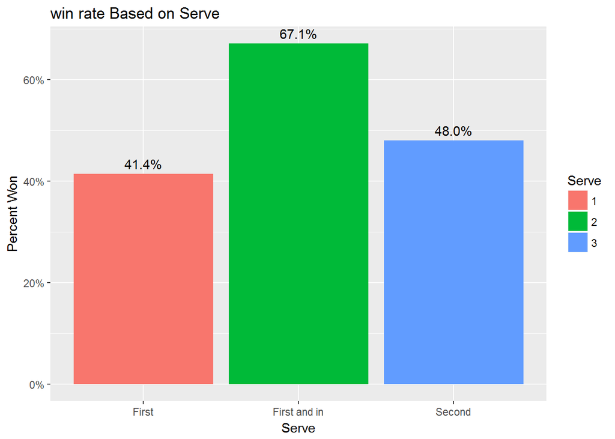

```r
db %>%
  rbind(db %>% filter(Serve == "First") %>% mutate(Serve = "First and in")) %>%
  group_by(Serve) %>%
  count(Won) %>%
  mutate("total" = if_else(Serve == "First and in", sum(n) - sum(db$Serve == "Second"), sum(n))) %>%
  mutate("perc" = n/total) %>%
  filter(Won == TRUE) %>%
  ggplot(aes(x = Serve, y = perc)) +
    geom_col(aes(fill = factor(..x..))) +
    scale_y_continuous(labels=scales::percent) +
    ggtitle("win rate Based on Serve") +
    geom_text(aes(label = scales::percent(perc), vjust = -.5)) +
    labs(y = "Percent Won", fill = "Serve")
```

This is more like it. This statistic is what started it all. Whenever they show first serve win percentage on television they show this statistic.

Now is the most fun part about our data analysis where we think about the information we gathered and make more questions about the topic from it.

## 7 - Analyse and Define New Goals

It is clear that first serves don’t win as much as second serves. Knowing that if we didn’t consider a first serve fault to be a first serve loss, we know that it is all the misses that bring down the win rate. Now why does the first serve miss so often? The risk with a strong first serve must be the culprit. We can ask a whole new set of questions from this analysis.

How do first serve and second serve speeds vary? How much does speed factor into missing a serve? Are you more likely to win with a faster serve? Do people serve more or less aggressively when it is a breakpoint?

Since our original dataset only included serve speed data on the last serve, we only have speeds for serves that were in. This means we won’t be able to answer all these questions but we still have data to answer most of them.

Let’s jump back into the analysis and find out some answers!

## 8 - Visualizing More Data

Most of these questions have to do with the speed of the serve so I think it would be a good idea just to get some basic plots of serve speed down. Sadly we only have serve speed data for a bit more than half the data.

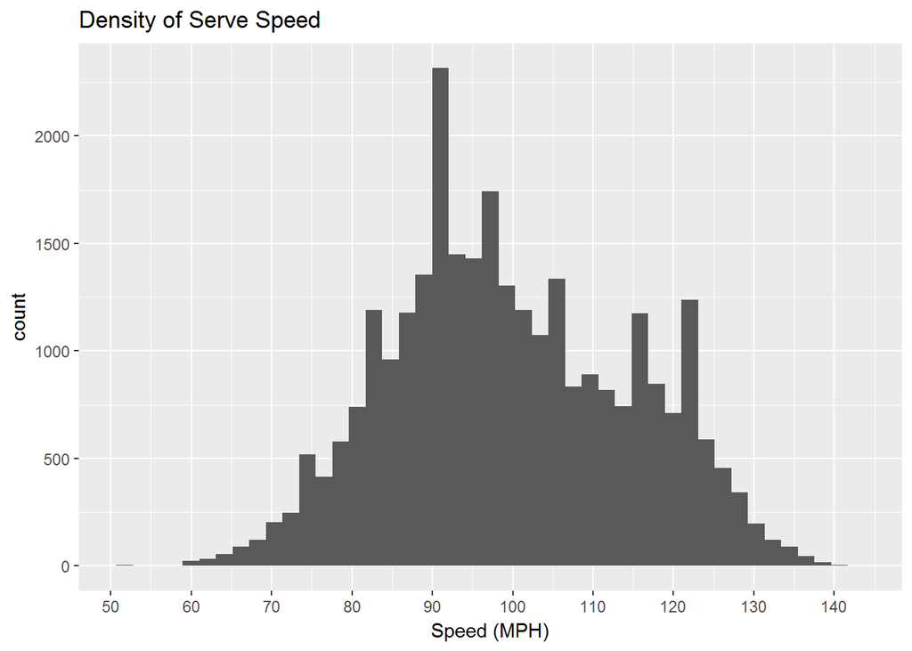

```r
db %>%
  filter(!is.na(Speed)) %>%
  ggplot(aes(x = Speed)) +
    geom_histogram(bins = 45) +
    ggtitle("Density of Serve Speed") +
    scale_x_continuous(breaks = seq(50, 160, 10)) +
    labs(x = "Speed (MPH)")
```

Lets see if we can better represent the two modes by separating our data based on serve.

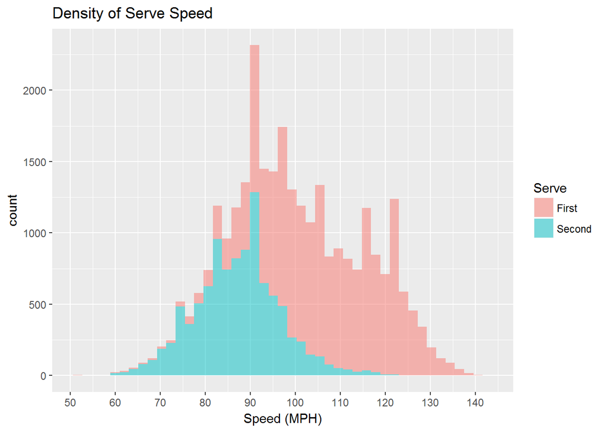

```r
db %>%
  filter(!is.na(Speed)) %>%
  ggplot(aes(x = Speed, fill = Serve)) +
    geom_histogram(alpha = .5, bins = 45) +
    ggtitle("Density of Serve Speed") +
    scale_x_continuous(breaks = seq(50, 160, 10)) +
    labs(x = "Speed (MPH)")
```

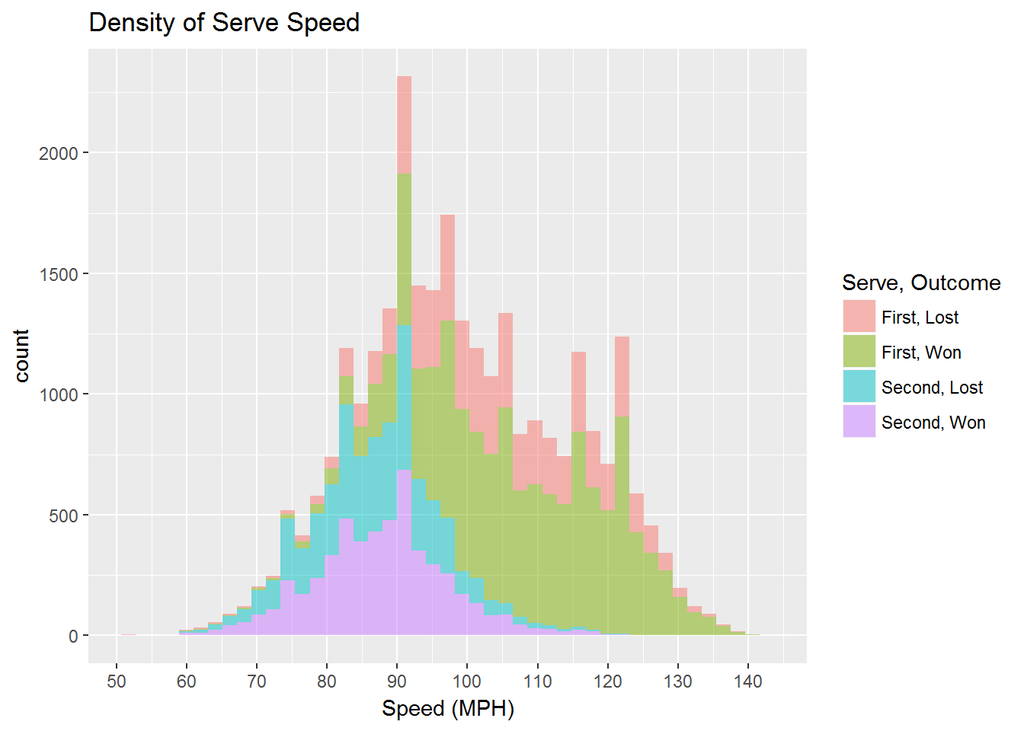

```r
db %>%
  filter(!is.na(Speed)) %>%
  mutate("ServeWon" = if_else(Won, paste(Serve, ", Won", sep = ""), paste(Serve, ", Lost", sep = ""))) %>%
  ggplot(aes(x = Speed, fill = ServeWon)) +
    geom_histogram(alpha = .5, bins = 45) +
    ggtitle("Density of Serve Speed") +
    scale_x_continuous(breaks = seq(50, 160, 10)) +
    labs(x = "Speed (MPH)", fill = "Serve, Outcome")
```

This is a very interesting plot. It shows that both our first serve and second serve tend to have a higher win rate with a higher speed. However the second serve win and loss are much closer together compared to the first serve. This means a faster first serve that is in is more of an indicator of winning than a faster second serve that you get in.

Let’s move on to the next question; How much does speed factor in to missing a serve?

Since we don’t have perfect data and we specifically do not have the speed of any serve that was missed, we have to try to show this data in a different way. Since a missed first serve is a first serve, we can assume that missed first serves and points that ended on the first serves have similar speeds. We can also assume this for second serves.

We know that a missed first serve is the number of second serves. We also know that a missed second serve is a double fault. Since we have all of those statistics we can represent this in a graph.

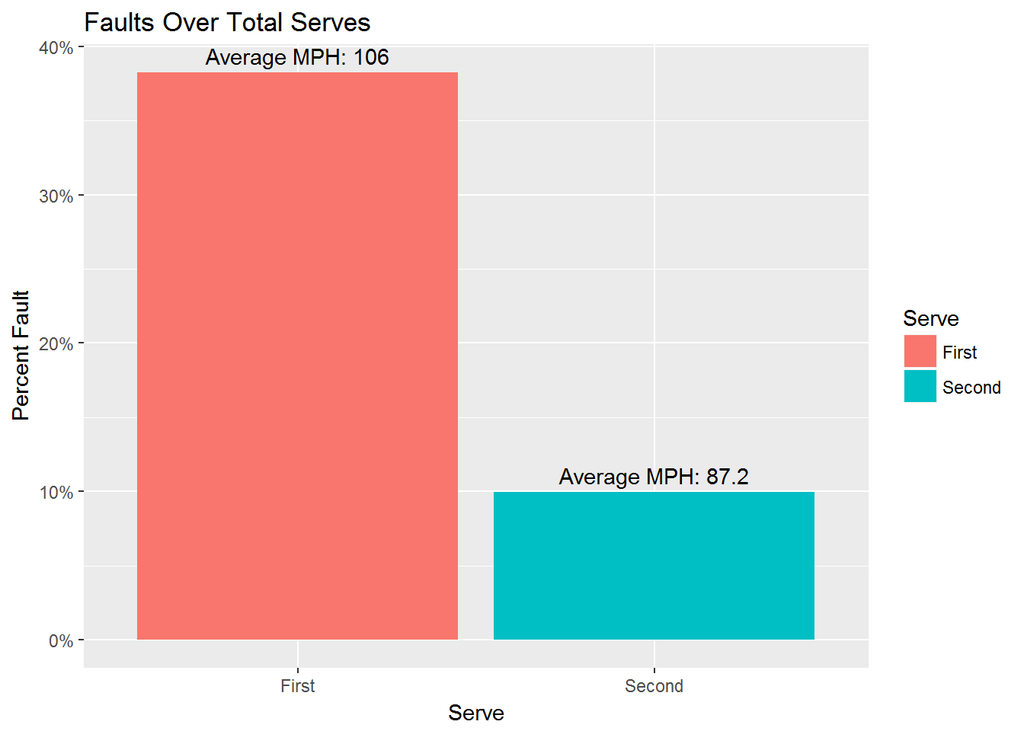

```r
db %>%
  group_by(Serve) %>%
  count(DoubleFault) %>%
  rename("Faults" = n) %>%
  mutate("Total" = sum(db$Serve == Serve)) %>%
  mutate("perc" = Faults/Total) %>%
  filter(DoubleFault) %>%
  select(Serve, perc) %>%
  rbind(db %>%
          count(Serve) %>%
          rename("Total" = n) %>%
          mutate("Faults" = Total[2]) %>%
          filter(Serve == "First") %>%
          mutate("perc" = Faults/Total) %>%
          select(Serve, perc)) %>%
  as.data.frame() %>%
  mutate("Serve" = as.character(Serve)) %>%
  mutate("perc" = as.double(perc)) %>%
  mutate("avgMPH" = if_else(Serve == "First", db %>%
                              filter(!is.na(Speed) & Serve == "First") %>%
                              select(Speed) %>%
                              sum() / db %>%
                              filter(!is.na(Speed) & Serve == "First") %>%
                              select(Serve) %>% nrow(), db %>%
                              filter(!is.na(Speed) & Serve == "Second") %>%
                              select(Speed) %>%
                              sum() / db %>%
                              filter(!is.na(Speed) & Serve == "Second") %>%
                              select(Serve) %>% nrow())) %>%
  ggplot(aes(x = Serve, y = perc)) +
    geom_col(aes(fill = Serve)) +
    scale_y_continuous(labels = scales::percent) +
    ggtitle("Faults Over Total Serves") +
    geom_text(aes(label = paste("Average MPH:", signif(avgMPH, 3)), vjust = -.5)) +
    labs(y = "Percent Fault", fill = "Serve")
```

This graph shows that We do fault a higher percentage of first serves for a faster serve.

Lets plot the relationship of aces to serve speed.

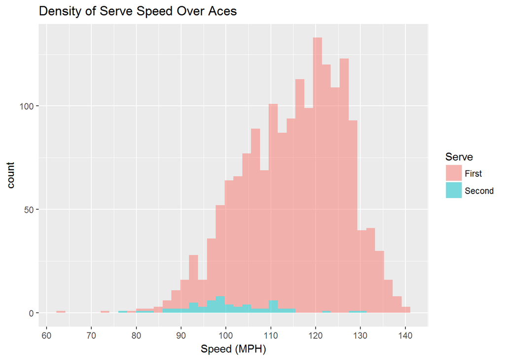

```r
db %>%
  filter(Ace & !is.na(Speed)) %>%
  ggplot(aes(x = Speed, fill = Serve)) +
    geom_histogram(alpha = .5, bins = 40) +
    ggtitle("Density of Serve Speed Over Aces") +
    scale_x_continuous(breaks = seq(50, 160, 10)) +
    labs(x = "Speed (MPH)", fill = "Serve")
```

We just have one relationship to look at last, breakpoint and how aggressive the serve is.

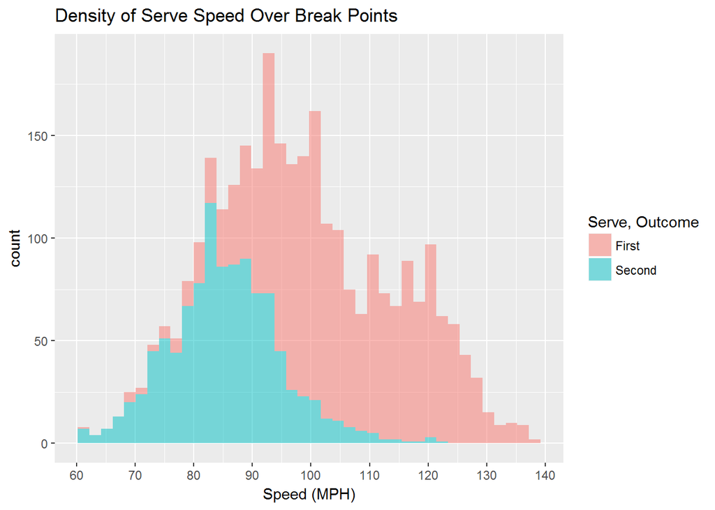

```r
db %>%
  filter(BreakPoint & !is.na(Speed)) %>%
  ggplot(aes(x = Speed, fill = Serve)) +
    geom_histogram(alpha = .5, bins = 40) +
    ggtitle("Density of Serve Speed Over Break Points") +
    scale_x_continuous(breaks = seq(50, 160, 10)) +
    labs(x = "Speed (MPH)", fill = "Serve, Outcome")
```

Let’s first look at the differences in serve speed.

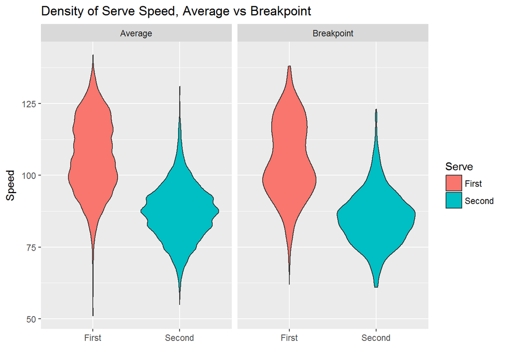

```r
BPSpeed <- db %>%
  filter(!is.na(Speed) & BreakPoint) %>%
  mutate(BP = "Breakpoint")

db %>%
  mutate(BP = "Average") %>%
  rbind(BPSpeed) %>%
  filter(!is.na(Speed)) %>%
  ggplot(aes(x = Serve, y = Speed, fill = Serve)) +
    geom_violin() +
    ggtitle("Density of Serve Speed, Average vs Breakpoint") +
    facet_grid(~BP, scales = "free") +
    labs(x = "")
```

This is a very interesting plot. It shows that on more important points people still serve nearly the same speed. There is about a 2 MPH decrease in serve speed on average over break points. I expected a much larger drop in first serve speed to reflect a more cautious serve similar to the second serve.

Lastly let’s look at the relationship between breakpoints and win rate.

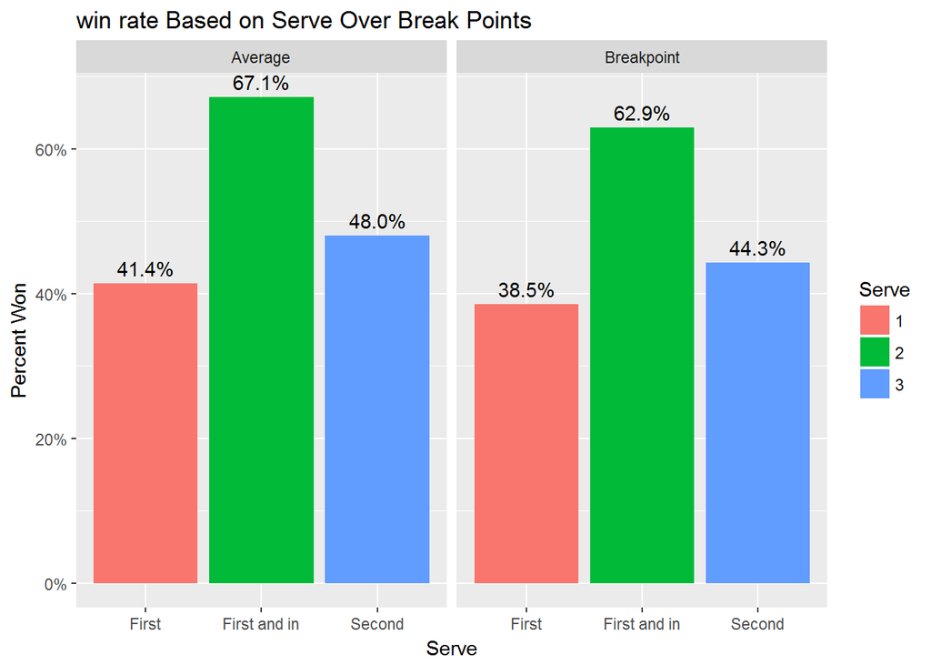

```r
BPWR <- db %>%
  filter(BreakPoint) %>%
  rbind(db %>%
          filter(Serve == "First" & BreakPoint) %>%
          mutate(Serve = "First and in")) %>%
  group_by(Serve) %>%
  count(Won) %>%
  mutate("total" = if_else(Serve == "First and in", sum(n) - sum(db$Serve == "Second" & db$BreakPoint), sum(n))) %>%
  mutate("perc" = n/total) %>%
  filter(Won == TRUE) %>%
  mutate("BP" = TRUE)

db %>%
  rbind(db %>% filter(Serve == "First") %>% mutate(Serve = "First and in")) %>%
  group_by(Serve) %>%
  count(Won) %>%
  mutate("total" = if_else(Serve == "First and in", sum(n) - sum(db$Serve == "Second"), sum(n))) %>%
  mutate("perc" = n/total) %>%
  filter(Won == TRUE) %>%
  mutate("BP" = FALSE) %>%
  rbind(BPWR) %>%
  mutate("BP" = if_else(BP, "Breakpoint", "Average")) %>%
  ggplot(aes(x = Serve, y = perc)) +
    geom_col(aes(fill = factor(..x..))) +
    scale_y_continuous(labels=scales::percent) +
    facet_grid(~BP) +
    ggtitle("win rate Based on Serve Over Break Points") +
    geom_text(aes(label = scales::percent(perc), vjust = -.5)) +
    labs(y = "Percent Won", fill = "Serve")
```

This is exactly the graph I was looking for! This is a crazy find. Basically it shows that people perform worse on breakpoints. Seems like the pressure really gets to people and makes their serves less potent when it really matters. It also could be because the receiver is also under pressure for breakpoints and possibly plays better as a result.

## 9 - Conclusion

So we can conclude that first serves, while they have a higher win rate when you include second serves, are less likely to be served in play, giving them a lower overall win rate. You definitely don’t want to serve your first serve as your second serve.

Also we can conclude that higher serve speed does in fact lead to a higher win rate but at the cost of a higher fault rate as well. This is why professionals have a flaming first serve in comparison to their second serve.

We also concluded that people usually serve worse when they are under the pressure of a breakpoint.

Overall it looks like the biggest way to improve your serving is not to speed up your second serve but to be more consistent serving break points.

It’s a shame the speed data was only for the last point served, otherwise I would be able to do a more in-depth analysis and calculate how win rate is a function of serve speed. All in all, I hope you had as much fun as me and maybe even learned something new!